# EDA, Cleaning/Processing and New Review Metric Creation.

## Analysing relationship of price with variables that we can use in the model

- I will use the data set for which the outliers are removed, and we get a more gaussian shape distribution.
- The variables related to the property will be analised first agiant the actual price/log price

```python
var_set_1 = [
'price',
'price_log',
'latitude',
'longitude',
'accommodates',
'bedrooms',
'beds',
'minimum_nights',
'maximum_nights',
'minimum_minimum_nights',
'maximum_minimum_nights',
'minimum_maximum_nights',
'maximum_maximum_nights',
'minimum_nights_avg_ntm',
'maximum_nights_avg_ntm',
'has_availability',
'availability_30',
'availability_60',
'availability_90',
'availability_365',
'bathrooms',
'bathrooms_shared',
'number_amenities',
'room_type_num']

var_amenties = ['wifi',
'heating',
'essentials',
'kitchen',
'smoke_alarm',
'washer',
'hangers',
'iron',
'tv',
'hair_dryer',
'shampoo',
'dedicated_workspace',
'carbon_monoxide_alarm',
'hot_water',
'dryer',
'refrigerator',
'dishes_and_silverware',
'cooking_basics',
'oven',
'bed_linens',
'microwave',
'stove',
'fire_extinguisher',
'first_aid_kit',
'private_entrance',
'dishwasher',
'coffee_maker',
'long_term_stays_allowed',
'elevator',
'free_parking_on_premises',
'extra_pillows_and_blankets',
'lock_on_bedroom_door',
'host_greets_you',
'cable_tv',
'luggage_dropoff_allowed',
'patio_or_balcony',
'garden_or_backyard',
'breakfast',
'paid_parking_off_premises',
'lockbox',
'free_street_parking',
'bathtub']

var_year = ['host_sice_YYYY', 'first_revie_YYYY', 'last_review_YYYY']
```

Some variables culd not have a linear relationships between them. Therefore, to measure the correlation between two variables, even their monotonically relationship is not linear, we used ht e Spearman correlation.

```python
corr_spear_set_1 = df_c[var_set_1].corr(method='spearman').abs()
```

```python
mtool.heat_map_corr(corr_spear_set_1, cmap='coolwarm', square=False, annot=True)
```

[figure not shown]

```python
corr_spear_amenities = df_c[['price', 'number_amenities'] + var_amenties].corr(method='spearman').abs()
```

```python
mtool.heat_map_corr(corr_spear_amenities, cmap='coolwarm', square=False, annot=True, figsize=(25,18))
```

[figure not shown]

```python
# data_set = os.path.join(path_input, 'extended_data_set.pickle')
# df_c = pd.read_pickle(data_set)
```

**Looking at the type of properties in the data set**

```python
plt.rcParams.update({'font.size': 18})
```

```python
# London Boroughs
fig, ax = plt.subplots(figsize=(25, 10))
df_c['neighbourhood_cleansed'].value_counts().plot(kind='bar', ax=ax)
plt.ylabel('Counts')
```

[figure not shown]

```python
# London Boroughs
fig, ax = plt.subplots(figsize=(25, 10))
(df_c['neighbourhood_cleansed'].value_counts() / df_c['neighbourhood_cleansed'].value_counts().sum() * 100).plot(kind='bar', ax=ax)
plt.ylabel('Percentage %')
```

[figure not shown]

```python
df_c_count_room_borough = df_c.groupby(['neighbourhood_cleansed', 'room_type'])['price'].count().to_frame('count')
```

```python
fig, ax = plt.subplots(figsize=(25, 10))
(df_c_count_room_borough.unstack().sum().sort_values(ascending=False)).plot(kind='bar', ax=ax)
plt.xticks(rotation=90)
plt.ylabel('Counts')
None
```

[figure not shown]

```python
fig, ax = plt.subplots(figsize=(25, 10))
(df_c_count_room_borough.unstack().sum().sort_values(ascending=False)/ df_c_count_room_borough.unstack().sum().sort_values(ascending=False).sum() * 100).plot(kind='bar', ax=ax)
plt.xticks(rotation=90)
plt.ylabel('Percentage %')
None
```

[figure not shown]

```python
color_01 = sns.color_palette('magma', n_colors=4, desat=.9)
```

```python
color_01 = sns.color_palette("colorblind")
```

```python
df_c_count_room_borough_asce = df_c_count_room_borough.unstack().sort_values(by=[('count', 'Entire home/apt'), ('count',    'Private room')], ascending=False)
```

```python
list_order_desc_labels = list(df_c_count_room_borough_asce.index.get_level_values(0))
```

```python
df_c_count_room_borough_asce.head()
```

| room_type neighbourhood_cleansed | count Entire home/apt | count Hotel room | count Private room | count Shared room |
| --- | --- | --- | --- | --- |
| Westminster | 6077.0 | 83.0 | 2178.0 | 45.0 |
| Kensington and Chelsea | 3911.0 | 152.0 | 1000.0 | 49.0 |
| Camden | 3363.0 | 68.0 | 1725.0 | 38.0 |
| Tower Hamlets | 3226.0 | 34.0 | 3514.0 | 60.0 |
| Hackney | 3112.0 | 12.0 | 2573.0 | 29.0 |

Looking at the split of the of properties at each Borough.

```python
fig, ax = plt.subplots(figsize=(25, 10))
df_c_count_room_borough_asce.plot(kind='bar', ax=ax, stacked=True, width=0.7, color=color_01, fontsize=22)
plt.xticks(rotation=90)
plt.ylabel('Counts')
plt.legend(prop={'size': 24})
None
```

[figure not shown]

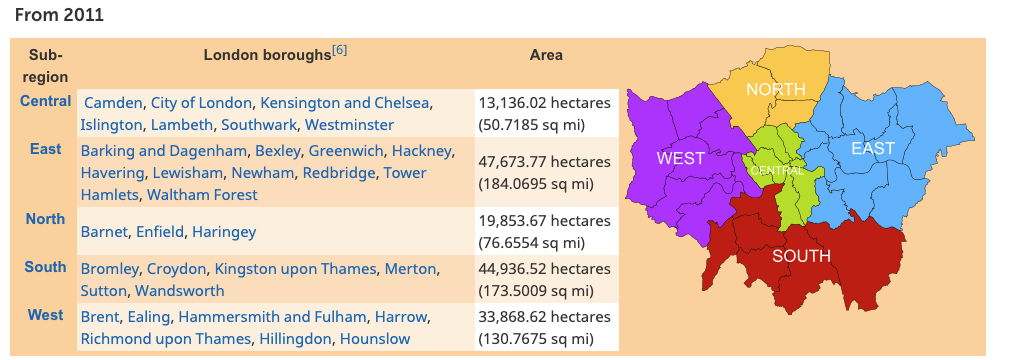

```python
df_c_count_room_borough.unstack().sum()
```

```
       room_type
count  Entire home/apt    41628.0
       Hotel room           556.0
       Private room       33338.0
       Shared room          592.0
dtype: float64
```

```python
df_c_count_room_borough_per = (df_c_count_room_borough.unstack() / df_c_count_room_borough.unstack().sum() * 100).sort_values(by=[('count', 'Entire home/apt')], ascending=False)
```

```python
df_c_count_room_borough_per.head()
```

| room_type neighbourhood_cleansed | count Entire home/apt | count Hotel room | count Private room | count Shared room |
| --- | --- | --- | --- | --- |
| Westminster | 14.598347 | 14.928058 | 6.533085 | 7.601351 |
| Kensington and Chelsea | 9.395119 | 27.338129 | 2.999580 | 8.277027 |
| Camden | 8.078697 | 12.230216 | 5.174276 | 6.418919 |
| Tower Hamlets | 7.749592 | 6.115108 | 10.540524 | 10.135135 |
| Hackney | 7.475737 | 2.158273 | 7.717919 | 4.898649 |

```python
fig, ax = plt.subplots(figsize=(25, 10))
df_c_count_room_borough_per.plot(kind='bar', ax=ax, stacked=False, width=0.7,
                                 color=color_01)
plt.xticks(rotation=90)
plt.ylabel('Percentage %')
None
```

[figure not shown]

Looking at the distributions of price per Borough.

```python
fig, ax = plt.subplots(figsize=(15, 7))
sns.violinplot(x="neighbourhood_cleansed", y="price", data=df_c, order=list_order_desc_labels)
plt.xticks(rotation=90)
None
```

[figure not shown]

```python
fig, ax = plt.subplots(figsize=(15, 7))
sns.violinplot(x="neighbourhood_cleansed", y="price_log", data=df_c, order=list_order_desc_labels)
plt.xticks(rotation=90)
None
```

[figure not shown]

```python
fig, ax = plt.subplots(figsize=(15, 7))
sns.boxplot(x="neighbourhood_cleansed", y="price", data=df_c, order=list_order_desc_labels)
plt.xticks(rotation=90)
None
```

[figure not shown]

```python
fig, ax = plt.subplots(figsize=(15, 7))
sns.boxplot(x="neighbourhood_cleansed", y="price_log", data=df_c, order=list_order_desc_labels)
plt.xticks(rotation=90)
None
```

[figure not shown]

```python
np.log(600)/np.log(1000)
```

```
0.9260504167945479
```

```python
fig, ax = plt.subplots(figsize=(25, 10))
sns.boxplot(x="neighbourhood_cleansed", y="price", hue='room_type',
            data=df_c, order=list_order_desc_labels, palette=color_01)
plt.xticks(rotation=90)
None
```

[figure not shown]

```python
fig, ax = plt.subplots(figsize=(25, 10))
sns.boxplot(x="neighbourhood_cleansed", y="price_log", hue='room_type',
            data=df_c, order=list_order_desc_labels, palette=color_01)
plt.xticks(rotation=90)
None
```

[figure not shown]

```python
fig, ax = plt.subplots(figsize=(25, 10))
sns.barplot(x="neighbourhood_cleansed", hue='room_type', y="price",
            data=df_c, order=list_order_desc_labels, palette=color_01,
           orient='v')
plt.xticks(rotation=90)
None
```

[figure not shown]

Looking at reviews

```python
color_02 = sns.color_palette('magma', n_colors=10, desat=.9)
```

```python
df_c_rev_score_values_borough = df_c.groupby(['neighbourhood_cleansed', 'review_scores_value'])['price'].count().to_frame('count')
```

```python
df_c_rev_score_values_borough_uns = df_c_rev_score_values_borough.unstack()
df_c_rev_score_values_borough_uns.head()
```

| review_scores_value neighbourhood_cleansed | count 2.0 | count 3.0 | count 4.0 | count 5.0 | count 6.0 | count 7.0 | count 8.0 | count 9.0 | count 10.0 |
| --- | --- | --- | --- | --- | --- | --- | --- | --- | --- |
| Barking and Dagenham | 3.0 | NaN | NaN | 1.0 | 3.0 | 4.0 | 25.0 | 62.0 | 123.0 |
| Barnet | 7.0 | NaN | 5.0 | 1.0 | 20.0 | 16.0 | 74.0 | 246.0 | 615.0 |
| Bexley | 2.0 | NaN | 1.0 | 1.0 | 3.0 | NaN | 11.0 | 31.0 | 106.0 |
| Brent | 8.0 | NaN | 10.0 | 2.0 | 27.0 | 17.0 | 150.0 | 538.0 | 840.0 |
| Bromley | 3.0 | NaN | 2.0 | 1.0 | 5.0 | 7.0 | 16.0 | 94.0 | 273.0 |

We can see that there are nulls. We already know from the missing data plot that about 30% of records are missing this score.

```python
df_c_rev_score_values_borough_uns = df_c_rev_score_values_borough_uns.reindex(list_order_desc_labels)
```

```python
fig, ax = plt.subplots(figsize=(30, 10))
df_c_rev_score_values_borough_uns.plot(kind='bar', ax=ax, stacked=True, width=0.7,
                                   fontsize=22, color=color_02)

plt.xticks(rotation=90)
plt.ylabel('Count')
None
```

[figure not shown]

```python
df_c_rev_score_values_borough_uns_per = (df_c_rev_score_values_borough_uns / df_c_rev_score_values_borough_uns.sum() * 100)
```

```python
df_c_rev_score_values_borough_uns_per.head()
```

| review_scores_value neighbourhood_cleansed | count 2.0 | count 3.0 | count 4.0 | count 5.0 | count 6.0 | count 7.0 | count 8.0 | count 9.0 | count 10.0 |
| --- | --- | --- | --- | --- | --- | --- | --- | --- | --- |
| Westminster | 12.312312 | 14.285714 | 15.346535 | 20.588235 | 12.801014 | 16.571429 | 14.783790 | 13.895988 | 7.873875 |
| Kensington and Chelsea | 8.708709 | 14.285714 | 8.415842 | 13.725490 | 6.970849 | 9.714286 | 9.123840 | 8.078675 | 5.212182 |
| Camden | 3.003003 | 14.285714 | 9.405941 | 4.901961 | 8.111534 | 9.285714 | 9.101200 | 8.545394 | 5.717975 |
| Tower Hamlets | 9.609610 | 28.571429 | 8.910891 | 10.784314 | 11.787072 | 11.285714 | 10.119991 | 9.789977 | 8.042472 |
| Hackney | 3.003003 | 14.285714 | 2.970297 | 1.960784 | 5.449937 | 4.857143 | 5.207154 | 7.328592 | 8.695340 |

```python
df_c_rev_score_values_borough_uns.sum()
```

```
       review_scores_value
count  2.0                      333.0
       3.0                        7.0
       4.0                      202.0
       5.0                      102.0
       6.0                      789.0
       7.0                      700.0
       8.0                     4417.0
       9.0                    17998.0
       10.0                   27877.0
dtype: float64
```

```python
fig, ax = plt.subplots(figsize=(30, 10))
df_c_rev_score_values_borough_uns_per.plot(kind='bar', ax=ax, stacked=False, width=0.7,
                                   fontsize=22, color=color_02)

plt.xticks(rotation=90)
plt.ylabel('Count')
None
```

[figure not shown]

```python
fig, ax = plt.subplots(figsize=(15, 7))
sns.boxplot(x="review_scores_value", y="price", data=df_c, palette=color_02)
plt.xticks(rotation=90)
None
```

[figure not shown]

```python
fig, ax = plt.subplots(figsize=(15, 7))
sns.boxplot(x="review_scores_value", y="price_log", data=df_c, palette=color_02)
plt.xticks(rotation=90)
None
```

[figure not shown]

```python
fig, ax = plt.subplots(figsize=(25, 10))
sns.boxplot(x="review_scores_value", y="price_log", hue='room_type',
            data=df_c, palette=color_01)
plt.xticks(rotation=90)
None
```

[figure not shown]

The price is not changing across all the scores. Like more score value more expensive I coild have thought that could happen sometimes.

```python
df_c.shape
```

```
(76114, 113)
```

```python
df_c['host_id'].nunique()
```

```
50654
```

```python
df_c.columns
```

```
Index(['id', 'description', 'neighborhood_overview', 'picture_url', 'host_id',
       'host_url', 'host_since', 'host_location', 'host_about',
       'host_response_time',
       ...
       'free_street_parking', 'bathtub', 'room_type_num',
       'months_since_first_reviews', 'months_with_reviews', 'months_as_host',
       'host_sice_YYYY', 'first_review_YYYY', 'last_review_YYYY', 'price_log'],
      dtype='object', length=113)
```

```python
df_c[['months_since_first_reviews', 'months_with_reviews', 'months_as_host',
       'host_sice_YYYY', 'first_review_YYYY', 'last_review_YYYY']].describe()
```

|  | months_since_first_reviews | months_with_reviews | months_as_host | host_sice_YYYY | first_review_YYYY | last_review_YYYY |
| --- | --- | --- | --- | --- | --- | --- |
| count | 54140.000000 | 54241.000000 | 76073.000000 | 76073.000000 | 54242.000000 | 54242.000000 |
| mean | 27.344403 | 16.860880 | 58.778936 | 2015.566324 | 2017.583238 | 2018.982781 |
| std | 25.043327 | 20.150501 | 28.012645 | 2.331693 | 1.800368 | 1.309584 |
| min | 0.000000 | 0.000000 | 0.000000 | 2008.000000 | 2009.000000 | 2011.000000 |
| 25% | 4.000000 | 1.000000 | 38.000000 | 2014.000000 | 2016.000000 | 2018.000000 |
| 50% | 22.000000 | 9.000000 | 61.000000 | 2015.000000 | 2018.000000 | 2019.000000 |
| 75% | 44.000000 | 26.000000 | 78.000000 | 2017.000000 | 2019.000000 | 2020.000000 |
| max | 141.000000 | 123.000000 | 148.000000 | 2020.000000 | 2021.000000 | 2021.000000 |

```python
df_c.groupby('host_since_YYYY')['price'].count()
```

[output not shown]

# Creating the 'overall_review_value' score metric

```python
# This data set contains the the predicted price
df_l = pd.read_pickle(os.path.join(path_input, 'extended_data_set_pred_01_GA.pick'))
```

```python
df_l.shape
```

```
(76114, 115)
```

```python
## This data set cotains the clean and tranformed text varibles (Texthero_Text_processing notebok)
df_pca = pd.read_pickle(os.path.join(path_input, 'extended_data_set_pred_01_pca.pick'))
```

```python
df_pca.shape
```

```
(76114, 135)
```

```python
df_pca = df_pca.filter(['desccription_pca_x', 'desccription_pca_y',
                        'neighborhood_overview_pca_x', 'neighborhood_overview_pca_y',
                       'predicted_price_log_01', 'predicted_price_01'])
```

```python
df_pca.head()
```

|  | desccription_pca_x | desccription_pca_y | neighborhood_overview_pca_x | neighborhood_overview_pca_y | predicted_price_log_01 | predicted_price_01 |
| --- | --- | --- | --- | --- | --- | --- |
| 0 | -0.207060 | -0.071857 | 0.115708 | -0.066403 | 4.345627 | 77.140373 |
| 1 | -0.156919 | -0.140670 | 0.126038 | -0.127408 | 3.829633 | 46.045658 |
| 2 | -0.078360 | -0.289400 | -0.203779 | 0.033219 | 4.821026 | 124.092384 |
| 3 | -0.065268 | -0.359259 | 0.042830 | -0.185334 | 5.457325 | 234.469376 |
| 4 | 0.018781 | 0.090359 | 0.127126 | -0.166530 | 4.347158 | 77.258614 |

```python
# Concatenating Data sets
df_pca_price_ga = pd.concat([df_l, df_pca], axis=1)
```

```python
df_pca_price_ga.shape
```

```
(76114, 121)
```

```python
df_pca_price_ga.head()
```

|  | id | description | neighborhood_overview | picture_url | host_id | host_url | host_since | host_location | host_about | host_response_time | host_response_rate | host_acceptance_rate | host_is_superhost | host_neighbourhood | host_listings_count | host_total_listings_count | host_verifications | neighbourhood | neighbourhood_cleansed | latitude | longitude | property_type | room_type | accommodates | bedrooms | beds | amenities | price | minimum_nights | … |
| --- | --- | --- | --- | --- | --- | --- | --- | --- | --- | --- | --- | --- | --- | --- | --- | --- | --- | --- | --- | --- | --- | --- | --- | --- | --- | --- | --- | --- | --- | --- |
| 0 | 11551 | Unlike most rental apartments out there my fla... | Not even 10 minutes by metro from Victoria Sta... | https://a0.muscache.com/pictures/b7afccf4-18e5... | 43039 | https://www.airbnb.com/users/show/43039 | 2009-10-03 | London, England, United Kingdom | Hello, I'm a friendly Italian man with a very ... | within an hour | 100.0 | 90.0 | 0.0 | Brixton | 3.0 | 3.0 | ['email', 'phone', 'reviews', 'jumio', 'offlin... | London, United Kingdom | Lambeth | 51.46225 | -0.11732 | Entire apartment | Entire home/apt | 4 | 1.0 | 3.0 | ["Refrigerator", "Kitchen", "Crib", "Dedicated... | 105.0 | 2 | … |
| 1 | 13913 | My bright double bedroom with a large window h... | Finsbury Park is a friendly melting pot commun... | https://a0.muscache.com/pictures/miso/Hosting-... | 54730 | https://www.airbnb.com/users/show/54730 | 2009-11-16 | London, England, United Kingdom | I am a Multi-Media Visual Artist and Creative ... | within a few hours | 100.0 | 75.0 | 0.0 | LB of Islington | 3.0 | 3.0 | ['email', 'phone', 'facebook', 'reviews', 'off... | Islington, Greater London, United Kingdom | Islington | 51.56802 | -0.11121 | Private room in apartment | Private room | 2 | 1.0 | 0.0 | ["Long term stays allowed", "Lock on bedroom d... | 40.0 | 1 | … |
| 2 | 15400 | Lots of windows and light. St Luke's Gardens ... | It is Chelsea. | https://a0.muscache.com/pictures/428392/462d26... | 60302 | https://www.airbnb.com/users/show/60302 | 2009-12-05 | Kensington, England, United Kingdom | English, grandmother, I have travelled quite ... | NaN | NaN | 100.0 | 0.0 | Chelsea | 1.0 | 1.0 | ['email', 'phone', 'reviews', 'jumio', 'govern... | London, United Kingdom | Kensington and Chelsea | 51.48796 | -0.16898 | Entire apartment | Entire home/apt | 2 | 1.0 | 1.0 | ["Refrigerator", "Wifi", "Heating", "Dishes an... | 75.0 | 10 | … |
| 3 | 17402 | You'll have a wonderful stay in this superb mo... | Location, location, location! You won't find b... | https://a0.muscache.com/pictures/39d5309d-fba7... | 67564 | https://www.airbnb.com/users/show/67564 | 2010-01-04 | London, England, United Kingdom | We are Liz and Jack. We manage a number of ho... | a few days or more | 0.0 | 100.0 | 1.0 | Fitzrovia | 18.0 | 18.0 | ['email', 'phone', 'reviews', 'jumio', 'offlin... | London, Fitzrovia, United Kingdom | Westminster | 51.52195 | -0.14094 | Entire apartment | Entire home/apt | 6 | 3.0 | 3.0 | ["Long term stays allowed", "Elevator", "Heati... | 307.0 | 4 | … |
| 4 | 17506 | Enjoy a chic stay in this elegant but fully mo... | Fulham is 'villagey' and residential – a real ... | https://a0.muscache.com/pictures/11901327/e63d... | 67915 | https://www.airbnb.com/users/show/67915 | 2010-01-05 | London, England, United Kingdom | Named best B&B by The Times. Easy going hosts,... | NaN | NaN | NaN | 0.0 | Fulham | 3.0 | 3.0 | ['email', 'phone', 'jumio', 'selfie', 'governm... | London, United Kingdom | Hammersmith and Fulham | 51.47935 | -0.19743 | Private room in townhouse | Private room | 2 | 1.0 | 1.0 | ["TV", "Hair dryer", "Lock on bedroom door", "... | 150.0 | 3 | … |

```python
#  Metrics to consider for a wighted average
list_scores_reviews = [
'review_scores_rating',
'review_scores_accuracy',
'review_scores_cleanliness',
'review_scores_checkin',
'review_scores_communication',
'review_scores_location',
'review_scores_value']
```

```python
df_scores_rev = df_pca_price_ga[list_scores_reviews].copy()
df_scores_rev.head()
```

|  | review_scores_rating | review_scores_accuracy | review_scores_cleanliness | review_scores_checkin | review_scores_communication | review_scores_location | review_scores_value |
| --- | --- | --- | --- | --- | --- | --- | --- |
| 0 | 91.0 | 9.0 | 9.0 | 10.0 | 10.0 | 9.0 | 9.0 |
| 1 | 97.0 | 10.0 | 10.0 | 10.0 | 10.0 | 9.0 | 9.0 |
| 2 | 96.0 | 10.0 | 10.0 | 10.0 | 10.0 | 10.0 | 9.0 |
| 3 | 94.0 | 10.0 | 9.0 | 9.0 | 9.0 | 10.0 | 9.0 |
| 4 | NaN | NaN | NaN | NaN | NaN | NaN | NaN |

```python
# Number of recods missing
missing_featrues = mtool.missing_data_size(df_scores_rev, figsize=(12, 5))
```

[figure not shown]

```python
# Percetage of recods missing
missing_feature_percetage = mtool.missing_data_percentage(df_scores_rev, missing_featrues, figsize=(12, 5))
```

[figure not shown]

```python
missing_feature_percetage
```

|  | Total | Percent | total not missing |
| --- | --- | --- | --- |
| review_scores_checkin | 23689 | 31.123052 | 52425 |
| review_scores_value | 23689 | 31.123052 | 52425 |
| review_scores_location | 23688 | 31.121738 | 52426 |
| review_scores_accuracy | 23642 | 31.061303 | 52472 |
| review_scores_communication | 23640 | 31.058675 | 52474 |
| review_scores_cleanliness | 23633 | 31.049478 | 52481 |
| review_scores_rating | 23583 | 30.983787 | 52531 |

```python
# Removing records where all the features are missing at the same time
mask = ((df_pca_price_ga['review_scores_checkin'].isnull()) &
        (df_pca_price_ga['review_scores_value'].isnull()) &
        (df_pca_price_ga['review_scores_location'].isnull()) &
        (df_pca_price_ga['review_scores_accuracy'].isnull()) &
        (df_pca_price_ga['review_scores_communication'].isnull()) &
        (df_pca_price_ga['review_scores_cleanliness'].isnull()) &
        (df_pca_price_ga['review_scores_rating'].isnull()))
```

```python
df_l_scores_r = df_pca_price_ga[~mask].copy()
```

```python
df_l_scores_r.shape
```

```
(52534, 121)
```

```python
# 68% of records will be used in the second model from the original data set
df_l_scores_r.shape[0] / df.shape[0] * 100
```

```
68.10568346816012
```

```python
# 69% of records will be used in the second model w.r.t the ones used in model 1
df_l_scores_r.shape[0] / df_pca_price_ga.shape[0] * 100
```

```
69.02015397955698
```

```python
df_l_scores_r[list_scores_reviews].head(10)
```

|  | review_scores_rating | review_scores_accuracy | review_scores_cleanliness | review_scores_checkin | review_scores_communication | review_scores_location | review_scores_value |
| --- | --- | --- | --- | --- | --- | --- | --- |
| 0 | 91.0 | 9.0 | 9.0 | 10.0 | 10.0 | 9.0 | 9.0 |
| 1 | 97.0 | 10.0 | 10.0 | 10.0 | 10.0 | 9.0 | 9.0 |
| 2 | 96.0 | 10.0 | 10.0 | 10.0 | 10.0 | 10.0 | 9.0 |
| 3 | 94.0 | 10.0 | 9.0 | 9.0 | 9.0 | 10.0 | 9.0 |
| 5 | 96.0 | 10.0 | 10.0 | 10.0 | 10.0 | 9.0 | 10.0 |
| 6 | 90.0 | 9.0 | 10.0 | 10.0 | 10.0 | 10.0 | 8.0 |
| 7 | 96.0 | 10.0 | 10.0 | 10.0 | 10.0 | 10.0 | 9.0 |
| 8 | 97.0 | 10.0 | 10.0 | 10.0 | 10.0 | 10.0 | 10.0 |
| 9 | 97.0 | 10.0 | 9.0 | 10.0 | 10.0 | 10.0 | 10.0 |
| 10 | 96.0 | 10.0 | 10.0 | 10.0 | 10.0 | 9.0 | 10.0 |

```python
df_l_scores_r[list_scores_reviews].describe()
```

|  | review_scores_rating | review_scores_accuracy | review_scores_cleanliness | review_scores_checkin | review_scores_communication | review_scores_location | review_scores_value |
| --- | --- | --- | --- | --- | --- | --- | --- |
| count | 52531.000000 | 52472.000000 | 52481.000000 | 52425.000000 | 52474.000000 | 52426.000000 | 52425.000000 |
| mean | 93.055091 | 9.527119 | 9.284732 | 9.650205 | 9.671190 | 9.556976 | 9.303329 |
| std | 10.506298 | 1.031211 | 1.184441 | 0.929281 | 0.925077 | 0.868308 | 1.075355 |
| min | 20.000000 | 2.000000 | 2.000000 | 2.000000 | 2.000000 | 2.000000 | 2.000000 |
| 25% | 90.000000 | 9.000000 | 9.000000 | 10.000000 | 10.000000 | 9.000000 | 9.000000 |
| 50% | 96.000000 | 10.000000 | 10.000000 | 10.000000 | 10.000000 | 10.000000 | 10.000000 |
| 75% | 100.000000 | 10.000000 | 10.000000 | 10.000000 | 10.000000 | 10.000000 | 10.000000 |
| max | 100.000000 | 10.000000 | 10.000000 | 10.000000 | 10.000000 | 10.000000 | 10.000000 |

```python
df_l_scores_r[list_scores_reviews] = df_l_scores_r[list_scores_reviews].fillna(0)
```

```python
# Scaling all the scores between 1 to 100 (just review_scores_rating is between this rage)
list_var_scaled = []
for col in list_scores_reviews[1:]:
    df_l_scores_r[col + '_scaled'] = df_l_scores_r[col] * 10
    list_var_scaled.append(col + '_scaled')
```

```python
df_l_scores_r[['review_scores_rating'] + list_var_scaled].describe()
```

|  | review_scores_rating | review_scores_accuracy_scaled | review_scores_cleanliness_scaled | review_scores_checkin_scaled | review_scores_communication_scaled | review_scores_location_scaled | review_scores_value_scaled |
| --- | --- | --- | --- | --- | --- | --- | --- |
| count | 52534.000000 | 52534.000000 | 52534.000000 | 52534.000000 | 52534.000000 | 52534.000000 | 52534.000000 |
| mean | 93.049777 | 95.158754 | 92.753645 | 96.301824 | 96.601439 | 95.373282 | 92.840256 |
| std | 10.529505 | 10.812663 | 12.199880 | 10.269361 | 9.805584 | 9.694307 | 11.546433 |
| min | 0.000000 | 0.000000 | 0.000000 | 0.000000 | 0.000000 | 0.000000 | 0.000000 |
| 25% | 90.000000 | 90.000000 | 90.000000 | 100.000000 | 100.000000 | 90.000000 | 90.000000 |
| 50% | 96.000000 | 100.000000 | 100.000000 | 100.000000 | 100.000000 | 100.000000 | 100.000000 |
| 75% | 100.000000 | 100.000000 | 100.000000 | 100.000000 | 100.000000 | 100.000000 | 100.000000 |
| max | 100.000000 | 100.000000 | 100.000000 | 100.000000 | 100.000000 | 100.000000 | 100.000000 |

```python
df_l_scores_r.isnull().any().to_frame().T
```

|  | id | description | neighborhood_overview | picture_url | host_id | host_url | host_since | host_location | host_about | host_response_time | host_response_rate | host_acceptance_rate | host_is_superhost | host_neighbourhood | host_listings_count | host_total_listings_count | host_verifications | neighbourhood | neighbourhood_cleansed | latitude | longitude | property_type | room_type | accommodates | bedrooms | beds | amenities | price | minimum_nights | … |
| --- | --- | --- | --- | --- | --- | --- | --- | --- | --- | --- | --- | --- | --- | --- | --- | --- | --- | --- | --- | --- | --- | --- | --- | --- | --- | --- | --- | --- | --- | --- |
| 0 | False | True | True | False | False | False | True | True | True | True | True | True | True | True | True | True | False | True | False | False | False | False | False | False | True | True | False | False | False | … |

A reminder of how to improve the chances for a listing to be ranked at the top [Ref 1](https://airbnbsmart.com/airbnb-ranking-strategy/):

- Pricing (it has the biggest overall impact on number of booking a listing will receive)
- Compleatness of the information on the listig (100% filled), and quality of the accuraccy of it.
- Quantity of images at least 15-20. the Airbnb algorithm thinks it is more accurrately representing the property, and therefore the experience.
- Good quality of pictures (higher resolutino).
- Image captions that is unique and not duplicated in other part.
- Quality and quantity of reviews
- Verification level
- airbnb host profile
- Instant book
- Minimum nightly stay
- host response time
- Location
- Vlick thorugh rate (number of clicks of guest)
- Time on listing page
- Booking rate (percentage of successful bookings in relation to the number of views a listing receives.)

**Weighted average**

```python
list_scores_reviews = [
'review_scores_rating',
'review_scores_accuracy',
'review_scores_cleanliness',
'review_scores_checkin',
'review_scores_communication',
'review_scores_location',
'review_scores_value']
```

```python
df_l_scores_r['overall_review_value'] = (df_l_scores_r['review_scores_value_scaled'] * 0.3 +
                                         df_l_scores_r['review_scores_accuracy_scaled'] * .2 +
                                         df_l_scores_r['review_scores_communication_scaled'] * .15 +
                                         df_l_scores_r['review_scores_rating'] * .1 +
                                         df_l_scores_r['review_scores_cleanliness_scaled'] * .1 +
                                         df_l_scores_r['review_scores_checkin_scaled'] * .1)
```

```python
df_l_scores_r[list_scores_reviews + ['overall_review_value']].head()
```

|  | review_scores_rating | review_scores_accuracy | review_scores_cleanliness | review_scores_checkin | review_scores_communication | review_scores_location | review_scores_value | overall_review_value |
| --- | --- | --- | --- | --- | --- | --- | --- | --- |
| 0 | 91.0 | 9.0 | 9.0 | 10.0 | 10.0 | 9.0 | 9.0 | 88.1 |
| 1 | 97.0 | 10.0 | 10.0 | 10.0 | 10.0 | 9.0 | 9.0 | 91.7 |
| 2 | 96.0 | 10.0 | 10.0 | 10.0 | 10.0 | 10.0 | 9.0 | 91.6 |
| 3 | 94.0 | 10.0 | 9.0 | 9.0 | 9.0 | 10.0 | 9.0 | 87.9 |
| 5 | 96.0 | 10.0 | 10.0 | 10.0 | 10.0 | 9.0 | 10.0 | 94.6 |

```python
df_l_scores_r['overall_review_value'].describe()
```

```
count    52534.000000
mean        89.584568
std          9.001203
min          2.000000
25%         87.900000
50%         92.000000
75%         94.900000
max         95.000000
Name: overall_review_value, dtype: float64
```

```python
df_l_scores_r['overall_review_value'].isnull().any()
```

```
False
```

```python
df_l_scores_r['host_number_verifications'] = df_l_scores_r['host_verifications'].apply(lambda x: len(x))
```

```python
df_l_scores_r['host_response_time'].value_counts(dropna=False)
```

```
NaN                   25594
within an hour        14519
within a few hours     5668
within a day           4783
a few days or more     1970
Name: host_response_time, dtype: int64
```

```python
# Map value increasing with time
map_host_response = {'within an hour':1, 'within a few hours':2, 'within a day':3, 'a few days or more':4}
```

```python
df_l_scores_r['host_response_time_category'] = df_l_scores_r['host_response_time'].map(map_host_response)
```

```python
df_l_scores_r['host_response_time_category'].value_counts(dropna=False)
```

```
NaN    25594
1.0    14519
2.0     5668
3.0     4783
4.0     1970
Name: host_response_time_category, dtype: int64
```

```python
df_l_scores_r.iloc[0].to_clipboard()
```

```python
# It is skewed
mtool.plotting_one_dist_norm_kde(df_l_scores_r, 'overall_review_value')
None
```

[figure not shown]

```python
mtool.stats_summary(df_l_scores_r[['overall_review_value']]).T
```

|  | overall_review_value |
| --- | --- |
| count | 52534.000000 |
| mean | 89.584568 |
| std | 9.001203 |
| min | 2.000000 |
| 25% | 87.900000 |
| 50% | 92.000000 |
| 75% | 94.900000 |
| max | 95.000000 |
| median | 92.000000 |
| skew | -4.363099 |
| kurt | 26.438822 |

```python
df_l_scores_r[df_l_scores_r['overall_review_value'] < 40].shape
```

```
(407, 131)
```

```python
df_l_scores_r.loc[df_l_scores_r['overall_review_value'] < 60].shape[0] / df_l_scores_r.shape[0] * 100
```

```
1.7588609281608103
```

```python
mtool.plotting_one_dist_norm_kde(df_l_scores_r.loc[df_l_scores_r['overall_review_value'] > 60],
                                 'overall_review_value')
None
```

[figure not shown]

```python
mtool.stats_summary(df_l_scores_r.loc[df_l_scores_r['overall_review_value'] > 60, ['overall_review_value']]).T
```

|  | overall_review_value |
| --- | --- |
| count | 51581.000000 |
| mean | 90.496212 |
| std | 5.640002 |
| min | 60.500000 |
| 25% | 88.100000 |
| 50% | 92.000000 |
| 75% | 94.900000 |
| max | 95.000000 |
| median | 92.000000 |
| skew | -1.951653 |
| kurt | 4.799616 |

```python
# Expliring distribution when tranformed to log
df_l_scores_r['overall_review_value_log'] = np.log(df_l_scores_r['overall_review_value'])
```

```python
mtool.plotting_one_dist_norm_kde(df_l_scores_r, 'overall_review_value_log')
None
```

[figure not shown]

The ditributions is skewed, and the outiers are not removed. I want the model also learns how poor reviews looks like. I want that or model also tell us informtation of that segment which is small.

```python
# df_l_scores_r.to_pickle(os.path.join(path_input, 'extended_data_set_pred_01_GA_pca.pick'))
```